# Relational data

## 13.2.1 Exercises

1. Imagine you wanted to draw (approximately) the route each plane flies from its origin to its destination. What variables would you need? What tables would you need to combine?

From `flights`, you would need `origin` and `dest`. From `airports`, `lat`, `lon` (the locations of the airport), and maybe `alt` would be required. You would need to combine the `flights` and `airports` tables to get the origin airport and destination airport.

The `weather` table may also be helpful as wind speed, wind direction, and visibility may affect the route.

2. I forgot to draw the relationship between `weather` and `airports`. What is the relationship and how should it appear in the diagram?

`weather` connects to `airports` via `origin` (the location). In the diagram, there should be an arrow pointing from `faa` in the `airports` table to `origin` in the `weather` table.

3. `weather` only contains information for the origin (NYC) airports. If it contained weather records for all airports in the USA, what additional relation would it define with `flights`?

`year`, `month`, `day`, and `hour`.

4. We know that some days of the year are “special”, and fewer people than usual fly on them. How might you represent that data as a data frame? What would be the primary keys of that table? How would it connect to the existing tables?

You would have date and name variables. The primary key of this table would be date. It would match to `year`, `month`, and `day` in other tables such as `flights`.

## 13.3.1 Exercises

1. Add a surrogate key to `flights`.

```r
flights %>%
  arrange(year, month, day, sched_dep_time) %>%
  mutate(flight_id = row_number())
```

```
## # A tibble: 336,776 x 20
##     year month   day dep_time sched_dep_time dep_delay arr_time
##    <int> <int> <int>    <int>          <int>     <dbl>    <int>
##  1  2013     1     1      517            515         2      830
##  2  2013     1     1      533            529         4      850
##  3  2013     1     1      542            540         2      923
##  4  2013     1     1      544            545        -1     1004
##  5  2013     1     1      554            558        -4      740
##  6  2013     1     1      559            559         0      702
##  7  2013     1     1      554            600        -6      812
##  8  2013     1     1      555            600        -5      913
##  9  2013     1     1      557            600        -3      709
## 10  2013     1     1      557            600        -3      838
## # ... with 336,766 more rows, and 13 more variables: sched_arr_time <int>,
## #   arr_delay <dbl>, carrier <chr>, flight <int>, tailnum <chr>,
## #   origin <chr>, dest <chr>, air_time <dbl>, distance <dbl>, hour <dbl>,
## #   minute <dbl>, time_hour <dttm>, flight_id <int>
```

2. Identify the keys in the following datasets
   1. `Lahman::Batting`,
   2. `babynames::babynames`
   3. `nasaweather::atmos`
   4. `fueleconomy::vehicles`
   5. `ggplot2::diamonds`

   (You might need to install some packages and read some documentation.)

`Lahman::Batting`:

The primary keys for `Lahman::Batting` are `playerID`, `yearID`, and `stint`.

```r
Lahman::Batting %>%
  count(playerID, yearID, stint) %>%
  filter(n > 1)
```

```
## # A tibble: 0 x 4
## # ... with 4 variables: playerID <chr>, yearID <int>, stint <int>, n <int>
```

`playerID` is a foreign key (it is the primary key for `Lahman::Master`).

`babynames::babynames`:

The primary keys for `babynames::babynames` are `year`, `sex`, and `name`.

```r
babynames::babynames %>%
  group_by(year, sex, name) %>%
  filter(n() > 1)
```

```
## # A tibble: 0 x 5
## # Groups:   year, sex, name [0]
## # ... with 5 variables: year <dbl>, sex <chr>, name <chr>, n <int>,
## #   prop <dbl>
```

`nasaweather::atmos`:

For `nasaweather:atmos`, the primary keys are `lat`, `long`, `year`, and `month`.

```r
nasaweather::atmos %>%
  group_by(lat, long, year, month) %>%
  filter(n() > 1)
```

```
## # A tibble: 0 x 11
## # Groups:   lat, long, year, month [0]
## # ... with 11 variables: lat <dbl>, long <dbl>, year <int>, month <int>,
## #   surftemp <dbl>, temp <dbl>, pressure <dbl>, ozone <dbl>,
## #   cloudlow <dbl>, cloudmid <dbl>, cloudhigh <dbl>
```

`fueleconomy::vehicles`:

The primary key for `fueleconomy::vehicles` is `id`.

```r
fueleconomy::vehicles %>%
  count(id) %>%
  filter(n > 1)
```

```
## # A tibble: 0 x 2
## # ... with 2 variables: id <int>, n <int>
```

`ggplot2::diamonds`:

`ggplot2::diamonds` does not appear to have a primary key.

```r
ggplot2::diamonds %>%
  group_by(carat, cut, color, clarity, depth, table, price, x, y, z) %>%
  filter(n() > 1) %>%
  nrow()
```

```
## [1] 289
```

3. Draw a diagram illustrating the connections between the `Batting`, `Master`, and `Salaries` tables in the Lahman package. Draw another diagram that shows the relationship between `Master`, `Managers`, `AwardsManagers`.

   How would you characterise the relationship between the `Batting`, `Pitching`, and `Fielding` tables?

## 13.4.6 Exercises

1. Compute the average delay by destination, then join on the `airports` data frame so you can show the spatial distribution of delays. Here’s an easy way to draw a map of the United States:

   ```r
   airports %>%
     semi_join(flights, c("faa" = "dest")) %>%
     ggplot(aes(lon, lat)) +
       borders("state") +
       geom_point() +
       coord_quickmap()
   ```

   (Don’t worry if you don’t understand what `semi_join()` does — you’ll learn about it next.)

   You might want to use the `size` or `colour` of the points to display the average delay for each airport.

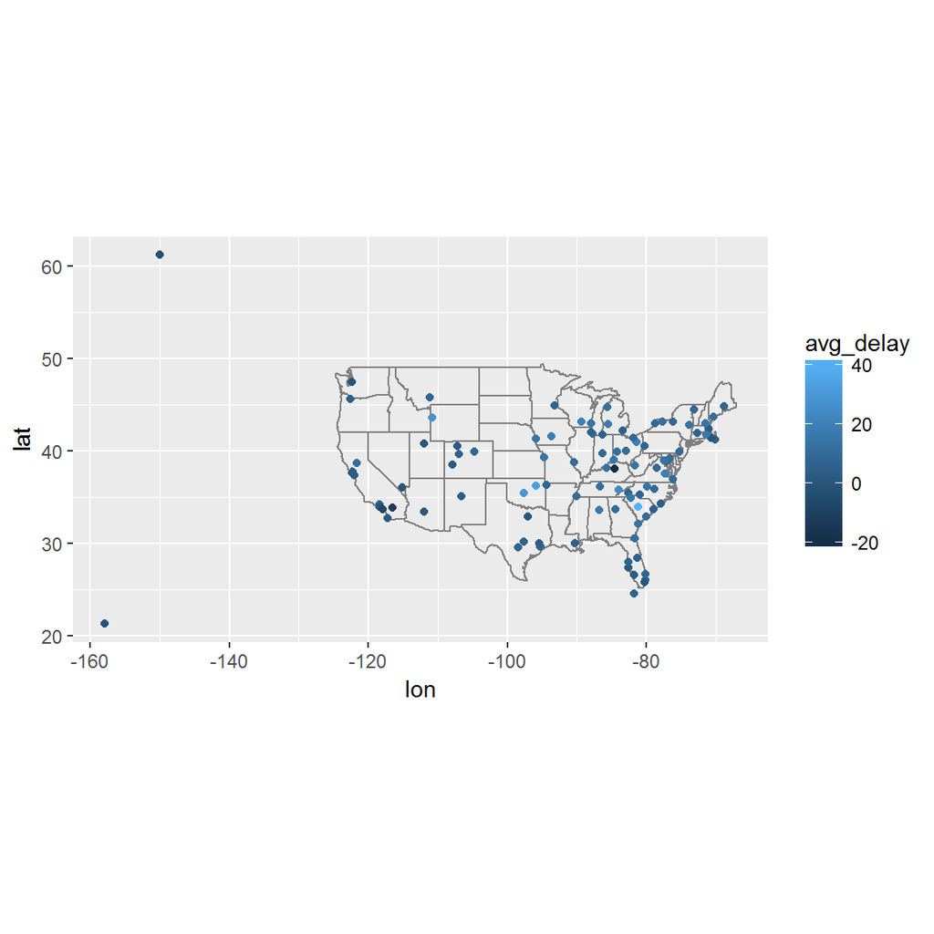

```r
dest_delay <- flights %>%
  group_by(dest) %>%
  summarise(avg_delay = mean(arr_delay, na.rm = TRUE))

dest_delay %>%
  left_join(airports, c("dest" = "faa")) %>%
  ggplot(aes(lon, lat)) +
    borders("state") +
    geom_point(aes(colour = avg_delay)) +
    coord_quickmap()
```

2. Add the location of the origin *and* destination (i.e. the `lat` and `lon`) to `flights`.

```r
flights %>%
  left_join(airports, c("origin" = "faa")) %>%
  left_join(airports, c("dest" = "faa")) %>%
  rename(lat_origin = lat.x, lon_origin = lon.x) %>%
  rename(lat_dest = lat.y, lon_dest = lon.y) %>%
  select(-contains("."))
```

```
## # A tibble: 336,776 x 23
##     year month   day dep_time sched_dep_time dep_delay arr_time
##    <int> <int> <int>    <int>          <int>     <dbl>    <int>
##  1  2013     1     1      517            515         2      830
##  2  2013     1     1      533            529         4      850
##  3  2013     1     1      542            540         2      923
##  4  2013     1     1      544            545        -1     1004
##  5  2013     1     1      554            600        -6      812
##  6  2013     1     1      554            558        -4      740
##  7  2013     1     1      555            600        -5      913
##  8  2013     1     1      557            600        -3      709
##  9  2013     1     1      557            600        -3      838
## 10  2013     1     1      558            600        -2      753
## # ... with 336,766 more rows, and 16 more variables: sched_arr_time <int>,
## #   arr_delay <dbl>, carrier <chr>, flight <int>, tailnum <chr>,
## #   origin <chr>, dest <chr>, air_time <dbl>, distance <dbl>, hour <dbl>,
## #   minute <dbl>, time_hour <dttm>, lat_origin <dbl>, lon_origin <dbl>,
## #   lat_dest <dbl>, lon_dest <dbl>
```

3. Is there a relationship between the age of a plane and its delays?

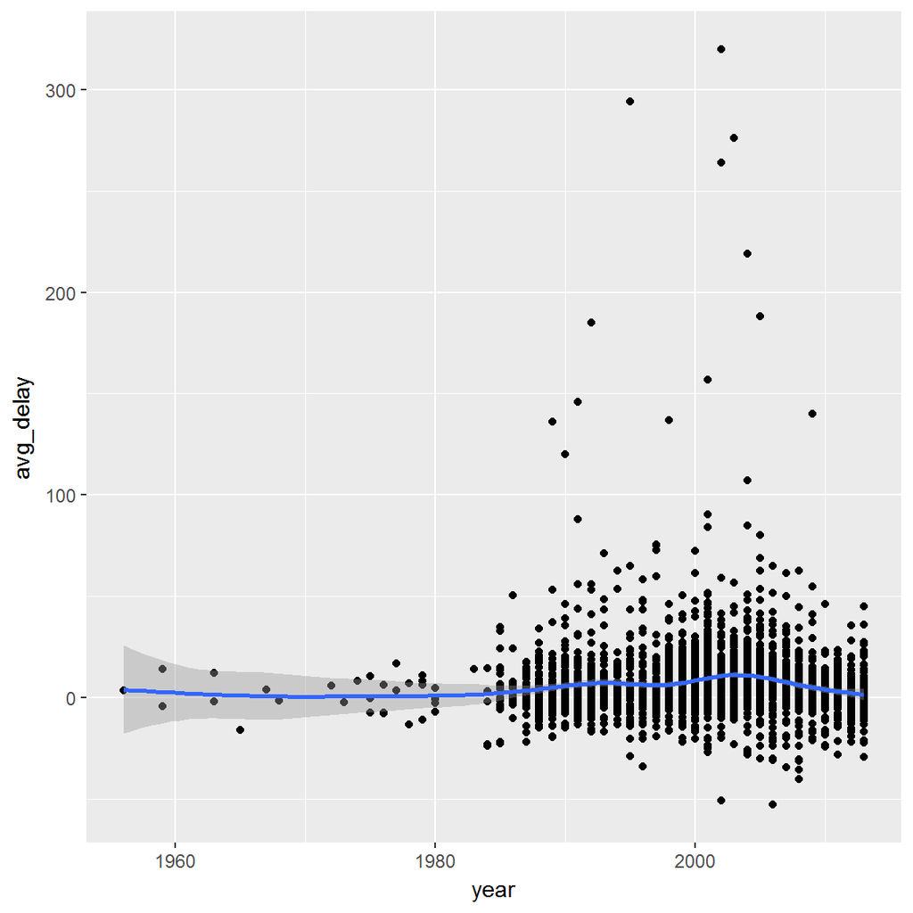

```r
planes_avg_delay <- planes %>%
  select(tailnum, year) %>%
  left_join(flights, "tailnum") %>%
  group_by(tailnum, year.x) %>%
  rename(year = year.x) %>%
  summarise(avg_delay = mean(arr_delay, na.rm = TRUE))

ggplot(planes_avg_delay, aes(year, avg_delay)) +
  geom_point() +
  geom_smooth()
```

It appears not.

4. What weather conditions make it more likely to see a delay?

I think rain and low visibility would increase the likelihood of delay.

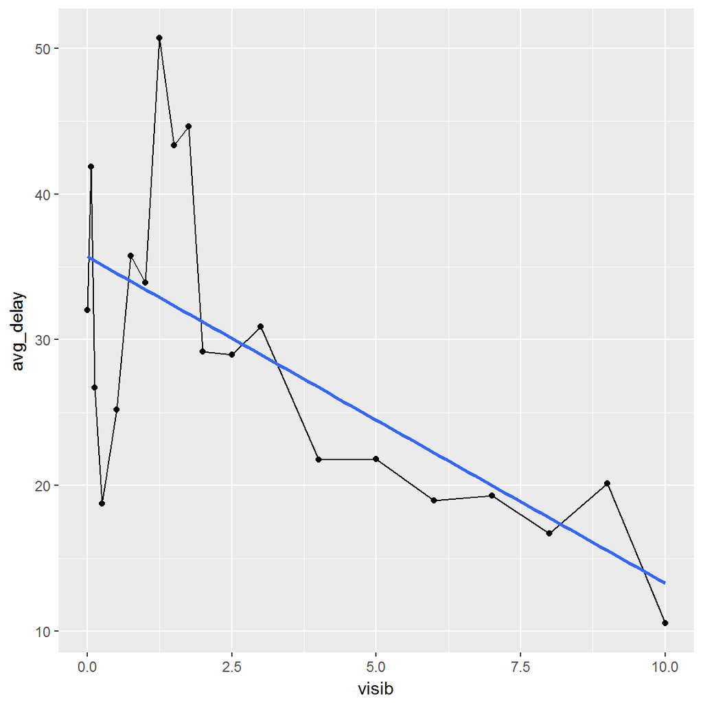

```r
flights_weather <- flights %>%
  inner_join(weather, c("origin", "year", "month", "day", "hour"))

flights_weather %>%
  group_by(visib) %>%
  summarise(avg_delay = mean(dep_delay, na.rm = TRUE)) %>%
  ggplot(aes(visib, avg_delay)) +
    geom_point() +
    geom_line() +
    geom_smooth(method = lm, se = FALSE)
```

As visibility increases, the average delay decreases.

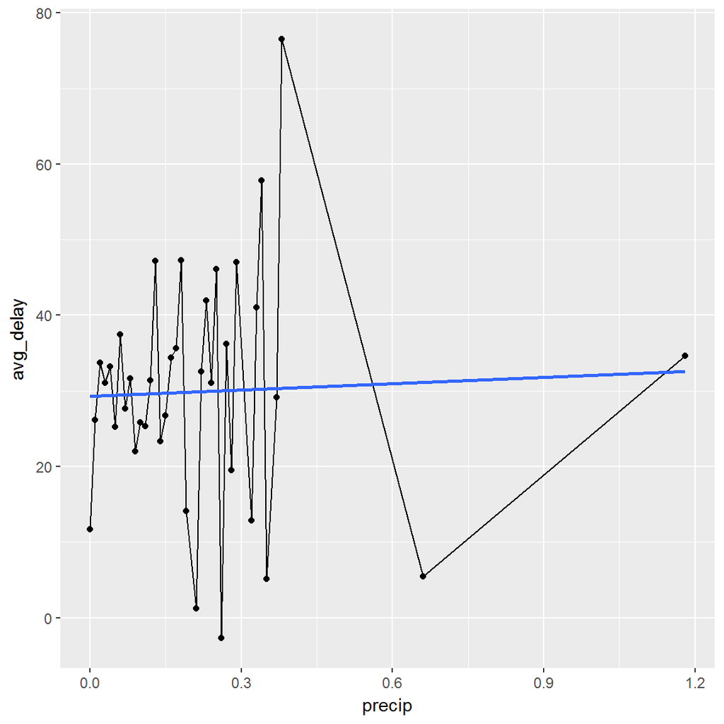

```r
flights_weather %>%
  group_by(precip) %>%
  summarise(avg_delay = mean(dep_delay, na.rm = TRUE)) %>%
  ggplot(aes(precip, avg_delay)) +
    geom_point() +
    geom_line() +
    geom_smooth(method = lm, se = FALSE)
```

The relationship between rainfall and average delay is less clear.

5. What happened on June 13 2013? Display the spatial pattern of delays, and then use Google to cross-reference with the weather.

There were a large series of storms in the south-east.

```r
flights %>%
  filter(month == 6, day == 13) %>%
  group_by(hour) %>%
  summarise(avg_delay = mean(dep_delay, na.rm = TRUE))
```

```
## # A tibble: 19 x 2
##     hour  avg_delay
##    <dbl>      <dbl>
##  1     5  -2.833333
##  2     6   3.542169
##  3     7   2.811594
##  4     8   7.913043
##  5     9  23.245283
##  6    10  27.818182
##  7    11  35.615385
##  8    12  61.340426
##  9    13  51.804348
## 10    14  61.543860
## 11    15  59.169231
## 12    16  52.000000
## 13    17  63.774648
## 14    18  70.000000
## 15    19  92.946429
## 16    20  87.897959
## 17    21  83.320000
## 18    22 103.111111
## 19    23  25.333333
```

By mid-morning there were significant delays. This continued into the evening.

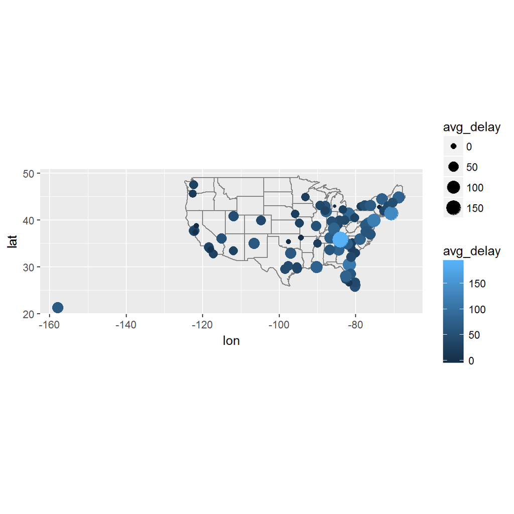

```r
flights %>%
  filter(month == 6, day == 13) %>%
  group_by(dest) %>%
  summarise(avg_delay = mean(dep_delay, na.rm = TRUE)) %>%
  inner_join(airports, by = c("dest" = "faa")) %>%
    ggplot(aes(lon, lat)) +
      borders("state") +
      geom_point(aes(colour = avg_delay, size = avg_delay)) +
      coord_quickmap()
```

## 13.5.1 Exercises

1. What does it mean for a flight to have a missing `tailnum`? What do the tail numbers that don’t have a matching record in `planes` have in common? (Hint: one variable explains ~90% of the problems.)

```r
flights %>%
  anti_join(planes, by = "tailnum")
```

```
## # A tibble: 52,606 x 19
##     year month   day dep_time sched_dep_time dep_delay arr_time
##    <int> <int> <int>    <int>          <int>     <dbl>    <int>
##  1  2013     1     1      558            600        -2      753
##  2  2013     1     1      559            600        -1      941
##  3  2013     1     1      600            600         0      837
##  4  2013     1     1      602            605        -3      821
##  5  2013     1     1      608            600         8      807
##  6  2013     1     1      611            600        11      945
##  7  2013     1     1      623            610        13      920
##  8  2013     1     1      624            630        -6      840
##  9  2013     1     1      628            630        -2     1137
## 10  2013     1     1      629            630        -1      824
## # ... with 52,596 more rows, and 12 more variables: sched_arr_time <int>,
## #   arr_delay <dbl>, carrier <chr>, flight <int>, tailnum <chr>,
## #   origin <chr>, dest <chr>, air_time <dbl>, distance <dbl>, hour <dbl>,
## #   minute <dbl>, time_hour <dttm>
```

Many of the flights without a tail number in `planes` appear to be American Airlines (`AA`) or Envoy Air (`MQ`).

```r
flights %>%
  anti_join(planes, by = "tailnum") %>%
  group_by(carrier) %>%
  summarise(count = n())
```

```
## # A tibble: 10 x 2
##    carrier count
##      <chr> <int>
##  1      9E  1044
##  2      AA 22558
##  3      B6   830
##  4      DL   110
##  5      F9    50
##  6      FL   187
##  7      MQ 25397
##  8      UA  1693
##  9      US   699
## 10      WN    38
```

```r
flights %>%
  anti_join(planes, by = "tailnum") %>%
  nrow()
```

```
## [1] 52606
```

Specifically, about 90% of flights.

2. Filter flights to only show flights with planes that have flown at least 100 flights.

```r
flights_100 <- flights %>%
  group_by(tailnum) %>%
  count() %>%
  filter(n >= 100 & tailnum != "NA") %>%
  arrange(desc(n))

flights %>%
  semi_join(flights_100, by = "tailnum")
```

```
## # A tibble: 228,390 x 19
##     year month   day dep_time sched_dep_time dep_delay arr_time
##    <int> <int> <int>    <int>          <int>     <dbl>    <int>
##  1  2013     1     1      517            515         2      830
##  2  2013     1     1      533            529         4      850
##  3  2013     1     1      544            545        -1     1004
##  4  2013     1     1      554            558        -4      740
##  5  2013     1     1      555            600        -5      913
##  6  2013     1     1      557            600        -3      709
##  7  2013     1     1      557            600        -3      838
##  8  2013     1     1      558            600        -2      849
##  9  2013     1     1      558            600        -2      853
## 10  2013     1     1      558            600        -2      923
## # ... with 228,380 more rows, and 12 more variables: sched_arr_time <int>,
## #   arr_delay <dbl>, carrier <chr>, flight <int>, tailnum <chr>,
## #   origin <chr>, dest <chr>, air_time <dbl>, distance <dbl>, hour <dbl>,
## #   minute <dbl>, time_hour <dttm>
```

3. Combine `fueleconomy::vehicles` and `fueleconomy::common` to find only the records for the most common models.

```r
fueleconomy::vehicles %>%
  semi_join(fueleconomy::common, by = c("make", "model"))
```

```
## # A tibble: 14,531 x 12
##       id  make   model  year           class           trans
##    <int> <chr>   <chr> <int>           <chr>           <chr>
##  1  1833 Acura Integra  1986 Subcompact Cars Automatic 4-spd
##  2  1834 Acura Integra  1986 Subcompact Cars    Manual 5-spd
##  3  3037 Acura Integra  1987 Subcompact Cars Automatic 4-spd
##  4  3038 Acura Integra  1987 Subcompact Cars    Manual 5-spd
##  5  4183 Acura Integra  1988 Subcompact Cars Automatic 4-spd
##  6  4184 Acura Integra  1988 Subcompact Cars    Manual 5-spd
##  7  5303 Acura Integra  1989 Subcompact Cars Automatic 4-spd
##  8  5304 Acura Integra  1989 Subcompact Cars    Manual 5-spd
##  9  6442 Acura Integra  1990 Subcompact Cars Automatic 4-spd
## 10  6443 Acura Integra  1990 Subcompact Cars    Manual 5-spd
## # ... with 14,521 more rows, and 6 more variables: drive <chr>, cyl <int>,
## #   displ <dbl>, fuel <chr>, hwy <int>, cty <int>
```

4. Find the 48 hours (over the course of the whole year) that have the worst delays. Cross-reference it with the `weather` data. Can you see any patterns?
5. What does `anti_join(flights, airports, by = c("dest" = "faa"))` tell you? What does `anti_join(airports, flights, by = c("faa" = "dest"))` tell you?

```r
anti_join(flights, airports, by = c("dest" = "faa"))
```

```
## # A tibble: 7,602 x 19
##     year month   day dep_time sched_dep_time dep_delay arr_time
##    <int> <int> <int>    <int>          <int>     <dbl>    <int>
##  1  2013     1     1      544            545        -1     1004
##  2  2013     1     1      615            615         0     1039
##  3  2013     1     1      628            630        -2     1137
##  4  2013     1     1      701            700         1     1123
##  5  2013     1     1      711            715        -4     1151
##  6  2013     1     1      820            820         0     1254
##  7  2013     1     1      820            820         0     1249
##  8  2013     1     1      840            845        -5     1311
##  9  2013     1     1      909            810        59     1331
## 10  2013     1     1      913            918        -5     1346
## # ... with 7,592 more rows, and 12 more variables: sched_arr_time <int>,
## #   arr_delay <dbl>, carrier <chr>, flight <int>, tailnum <chr>,
## #   origin <chr>, dest <chr>, air_time <dbl>, distance <dbl>, hour <dbl>,
## #   minute <dbl>, time_hour <dttm>
```

The destination of these flights is unknown (i.e., the airport does not appear in `airports`). They could be international flights.

```r
anti_join(airports, flights, by = c("faa" = "dest"))
```

```
## # A tibble: 1,357 x 8
##      faa                           name      lat        lon   alt    tz
##    <chr>                          <chr>    <dbl>      <dbl> <int> <dbl>
##  1   04G              Lansdowne Airport 41.13047  -80.61958  1044    -5
##  2   06A  Moton Field Municipal Airport 32.46057  -85.68003   264    -6
##  3   06C            Schaumburg Regional 41.98934  -88.10124   801    -6
##  4   06N                Randall Airport 41.43191  -74.39156   523    -5
##  5   09J          Jekyll Island Airport 31.07447  -81.42778    11    -5
##  6   0A9 Elizabethton Municipal Airport 36.37122  -82.17342  1593    -5
##  7   0G6        Williams County Airport 41.46731  -84.50678   730    -5
##  8   0G7  Finger Lakes Regional Airport 42.88356  -76.78123   492    -5
##  9   0P2   Shoestring Aviation Airfield 39.79482  -76.64719  1000    -5
## 10   0S9          Jefferson County Intl 48.05381 -122.81064   108    -8
## # ... with 1,347 more rows, and 2 more variables: dst <chr>, tzone <chr>
```

6. You might expect that there’s an implicit relationship between plane and airline, because each plane is flown by a single airline. Confirm or reject this hypothesis using the tools you’ve learned above.

```r
flights_carrier <- flights %>%
  group_by(tailnum, carrier) %>%
  count() %>%
  arrange(tailnum)
flights_carrier
```

```
## # A tibble: 4,067 x 3
## # Groups:   tailnum, carrier [4,067]
##    tailnum carrier     n
##      <chr>   <chr> <int>
##  1  D942DN      DL     4
##  2  N0EGMQ      MQ   371
##  3  N10156      EV   153
##  4  N102UW      US    48
##  5  N103US      US    46
##  6  N104UW      US    47
##  7  N10575      EV   289
##  8  N105UW      US    45
##  9  N107US      US    41
## 10  N108UW      US    60
## # ... with 4,057 more rows
```

```r
flights_carrier %>%
  group_by(tailnum) %>%
  count() %>%
  filter(nn > 1)
```

```
## # A tibble: 18 x 2
## # Groups:   tailnum [18]
##    tailnum    nn
##      <chr> <int>
##  1  N146PQ     2
##  2  N153PQ     2
##  3  N176PQ     2
##  4  N181PQ     2
##  5  N197PQ     2
##  6  N200PQ     2
##  7  N228PQ     2
##  8  N232PQ     2
##  9  N933AT     2
## 10  N935AT     2
## 11  N977AT     2
## 12  N978AT     2
## 13  N979AT     2
## 14  N981AT     2
## 15  N989AT     2
## 16  N990AT     2
## 17  N994AT     2
## 18    <NA>     7
```

There are a number of planes that have been flown by multiple airlines. However, the majority of planes have had a single airline.